# Assignment 2

Bayesian Statistics

Daniel Carpenter

March 2022

> Goal of Assignment:
- Use `mix-beta distribution` for a prior in JAGS MCMC model
- Must use `pseudo prior`, *or the posterior from the first JAGS run*, then run model again
- Then, the posterior distribution will be correct

# Task `1` - Get `General Posterior` given `Beta Prior` and `Binomial Likelihood`

## `a` Bayes Thereom

$$\underbrace{p(\theta \mid D)}_{\text {posterior }}
=\underbrace{p(D \mid \theta)}_{\text {likelihood}} \times
\underbrace{p(\theta)}_{\text {prior}}
/ \underbrace{p(D)}_{\text {evidence }}$$

## `b` General Posterior

> Derive the general posterior result for a Beta prior and Binomial likelihood

*Taken from JK’s book - page 132 Doing Bayesian Data Analysis:*

#### Bayes’ rule

$p(\theta \mid z, N)=p(z, N \mid \theta) p(\theta) / p(z, N)$

#### Define Bernoulli and beta distributions

$=\theta^{z}(1-\theta)^{(N-z)} \frac{\theta^{(a-1)}(1-\theta)^{(b-1)}}{B(a, b)} / p(z, N)$

#### Rearrange factors

$=\theta^{z}(1-\theta)^{(N-z)} \theta^{(a-1)}(1-\theta)^{(b-1)} /[B(a, b) p(z, N)] \quad$

#### Collect Powers

$=\theta^{((z+a)-1)}(1-\theta)^{((N-z+b)-1)} /[B(a, b) p(z, N)] \quad$  
$=\theta^{((z+a)-1)}(1-\theta)^{((N-z+b)-1)} / B(z+a, N-z+b)$

## `c` Plot Prior, Likelihood, and Posterior

- Given uniform prior (for a Beta prior and Binomial likelihood)

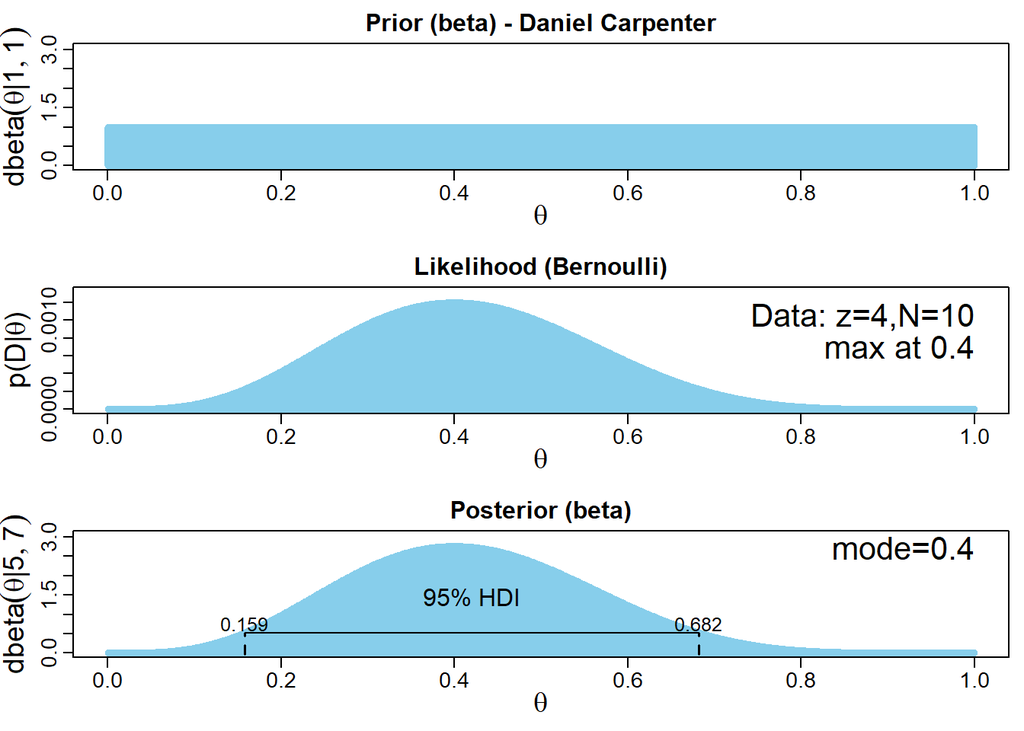

```r
source("DBDA2E-utilities.R")  # Load definitions of graphics functions etc.
source("BernBeta.R")          # Load the definition of the BernBeta function

# Specify the prior:
t = 4              # Specify the prior MODE.
n = 10               # Specify the effective prior sample size.
a = 1                # Convert to beta shape parameter a.
b = 1                # Convert to beta shape parameter b.

Prior = c(a,b)       # Specify Prior as vector with the two shape parameters.

# Specify the data:
N = 10                         # The total number of flips.
z = 4                         # The number of heads.
Data = c(rep(0,N-z),rep(1,z))  # Convert N and z into vector of 0's and 1's.


# Plot the three graphs
posterior = BernBeta( priorBetaAB=Prior, Data=Data , plotType="Bars" ,
                      showCentTend="Mode" , showHDI=TRUE , showpD=FALSE )
```

## `d` `Mybeta()` - Plot Prior, Likelihood, and Posterior

- Function to Plot Prior, Likelihood, and Posterior
- Beta prior and Binomial likelihood

```r
# Create flexible function that plots the Prior, Likelihood, and Posterior
# Given a Beta prior and Binomial likelihood
Mybeta <- function(alpha = 1, beta = 1, n, x) {

  source("DBDA2E-utilities.R")  # Load definitions of graphics functions etc.
  source("BernBeta.R")          # Load the definition of the BernBeta function

  # Specify the prior:
  t = x                          # Specify the prior MODE.

  Prior = c(alpha,beta)          # Specify Prior as vector with the two shape parameters.

  # Specify the data:
  N = n                          # The total number of flips.
  z = x                          # The number of heads.
  Data = c(rep(0,N-z),rep(1,z))  # Convert N and z into vector of 0's and 1's.

  # Make plots for prior, lik, and post
  posterior = BernBeta( priorBetaAB=Prior, Data=Data , plotType="Bars" ,
                        showCentTend="Mode" , showHDI=TRUE , showpD=FALSE )
}
```

## `e` Call `Mybeta()` given various paramters

```r
  Mybeta(alpha=2, beta=2, n=10, x=6)
```

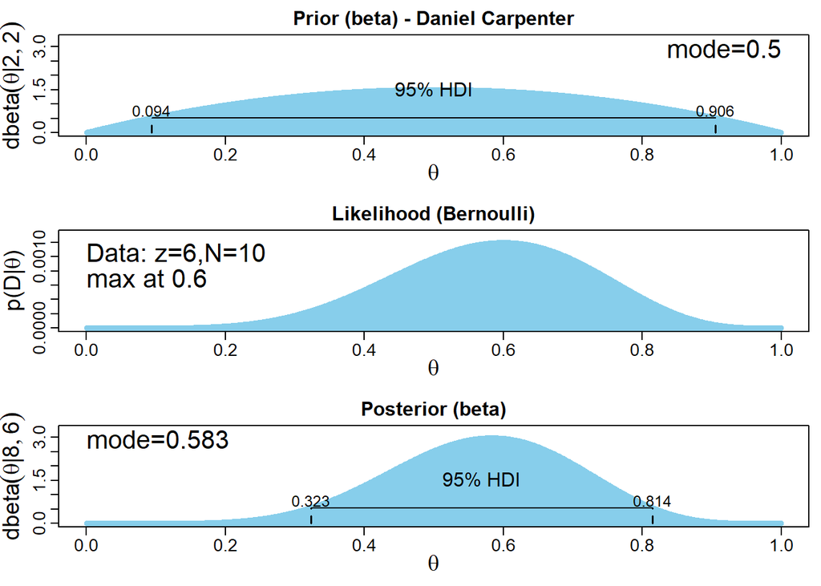

```r
  Mybeta(alpha=4, beta=2, n=10, x=6)
```

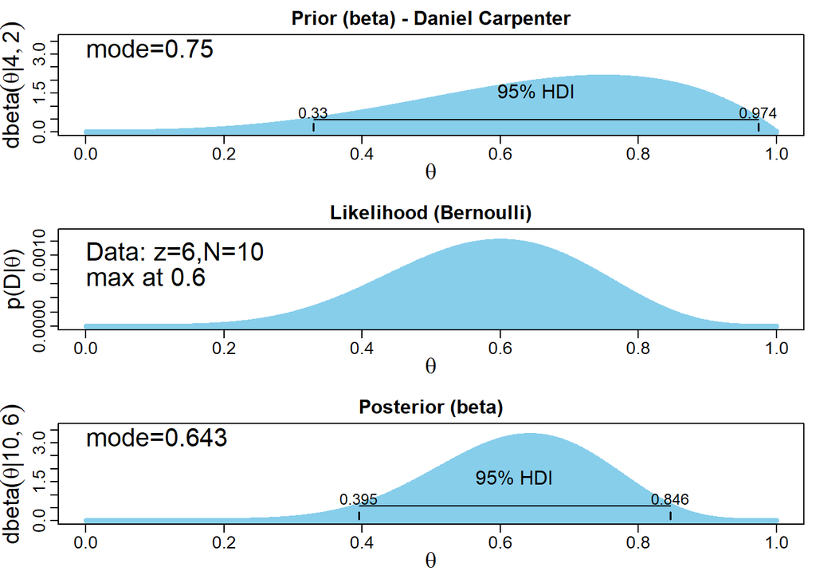

```r
  Mybeta(alpha=2, beta=4, n=10, x=6)
```

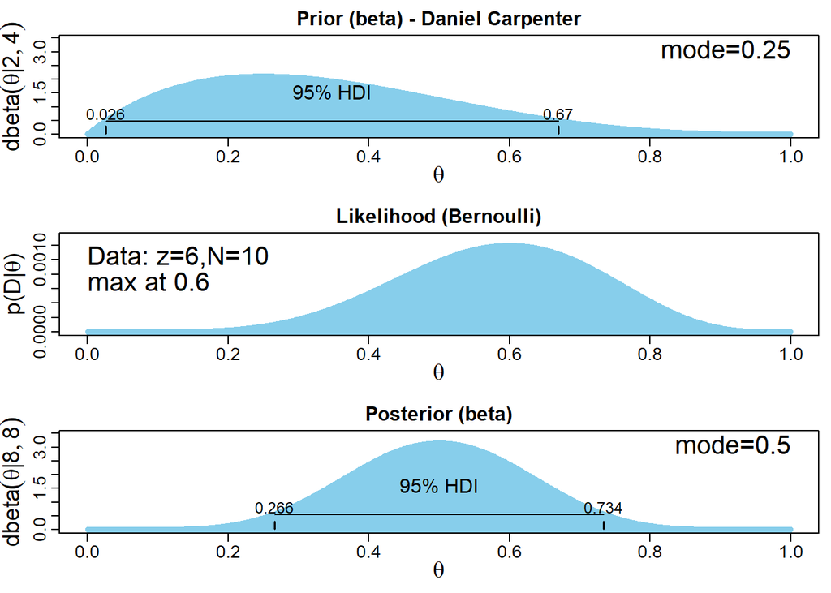

```r
  Mybeta(alpha=20, beta=20, n=10, x=6)
```

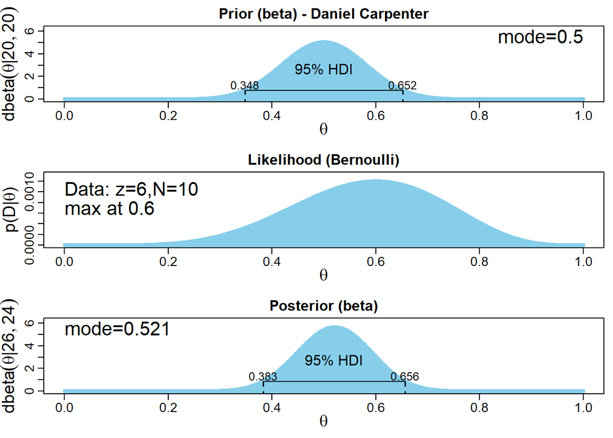

## `f` `Mybeta2()` - Includes `CMD` Output

- Adjusted function `Mybeta2()` that produces the same plots as `mybeta()`
- but releases command line Bayesian point estimates and BCI’s of whatever equal tail size we wish – all estimating `p`

```r
Mybeta2 <- function(alpha = 1, beta = 1, n, x, alphalevel=0.05) {

  source("DBDA2E-utilities.R")  # Load definitions of graphics functions etc.
  source("BernBeta.R")          # Load the definition of the BernBeta function

  # Specify the prior:
  t = x                          # Specify the prior MODE.

  Prior = c(alpha,beta)          # Specify Prior as vector with the two shape parameters.

  # Specify the data:
  N = n                          # The total number of flips.
  z = x                          # The number of heads.
  Data = c(rep(0,N-z),rep(1,z))  # Convert N and z into vector of 0's and 1's.

  # Make plots for prior, lik, and post
  posterior = BernBeta( priorBetaAB=Prior, Data=Data , plotType="Bars" ,
                        showCentTend="Mode" , showHDI=TRUE , showpD=FALSE )

  # Get alpha and beta used to form the posterior distribution
  postAlpha = posterior[1]
  postBeta  = posterior[2]

  # Calculate the HDI Tails
  lowerLevel = (alphalevel / 2)
  upperLevel = (1 - alphalevel / 2)
  HDI = qbeta(c(lowerLevel, upperLevel), postAlpha, postBeta)

  # Return the Lower and Upper HDI at the given level of alpha
  return(list('lowerHDI' = HDI[1],
              'upperHDI' = HDI[2]))
}
```

- *Note that that R Markdown will not recreate the graphs since they are the same, but the `CMD` output is shown*

```r
# Call the above function under various parameter scenarios
Mybeta2(alpha = 2, beta=2, n=10, x=4, alphalevel=0.05)
```

```
## $lowerHDI
## [1] 0.1922324
##
## $upperHDI
## [1] 0.6842224
```

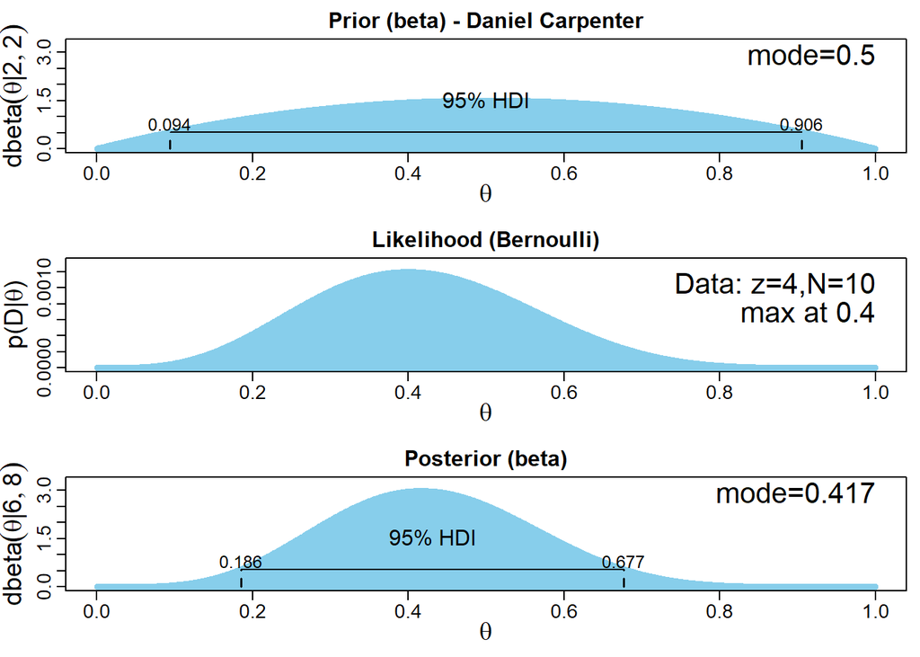

```
## $lowerHDI
## [1] 0.2239554
##
## $upperHDI
## [1] 0.6452007
```

```r
Mybeta2(alpha = 2, beta=2, n=10, x=4, alphalevel=0.10)
```

```r
Mybeta2(alpha = 2, beta=2, n=10, x=3, alphalevel=0.05)
```

```
## $lowerHDI
## [1] 0.1385793
##
## $upperHDI
## [1] 0.6142617
```

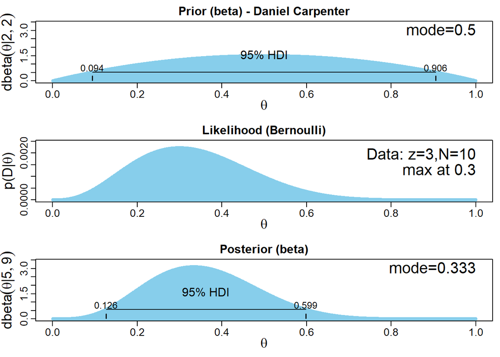

```
## $lowerHDI
## [1] 0.09422851
##
## $upperHDI
## [1] 0.6912766
```

```r
Mybeta2(alpha = 2, beta=2, n=10, x=3, alphalevel=0.01)
```

# Task `2` - Mix 2-Beta Distributions as Prior Distribution

## `a` Show that mixbeta satisfies the first 2/3 properties of a density.

### Analytical Assumptions about Mized Betas

#### 1. Two beta distributions with two shape parameters

$$dbeta1 = dbeta(x, a1, b1) \\
dbeta2 = dbeta(x, a2, b2)$$

#### 2. The sum of w is 1

$$\sum_{-\infty}^{+\infty} w = 1$$

### Explanation of above

1. $f(x) \geq 0$
- Answer: The area under a beta distribution is from 0 to 1. Since the sum of the weight $w$ is 1, the area of both weighted betas will be 1.

$$dbeta(x, a, b)=\frac{x^{a-1}(1-x)^{b-1}}{B(a, b)} \geq 0$$

2. $\int_{-\infty}^{+\infty} f(x) d x=1$
- Answer: If the sum of the weight $w$ is 1, and the area under a beta distribution must always be 1, then the area from -$\infty$ to +$\infty$ will cover that interval and sum to 1, making $\int_{-\infty}^{+\infty} f(x) d x=1$

$$\begin{gathered}
\text { If, } \int_{-\infty}^{\infty} dbeta(x, a, b) d x = \int_{-\infty}^{\infty} \frac{x^{a-1}(1-x)^{b-1}}{B(a, b)} d x=1 \\
\text { Then, } \int_{-\infty}^{\infty} dbeta(x, a 1, b 1) d x=1 \\
\text { and } \int_{-\infty}^{\infty} dbeta(x, a 2, b 2) d x=1 \\
\text { Therefore, } \int_{-\infty}^{\infty} w * dbeta(x, a 1, b 1) d x=w * 1 \\
\text { and } \int_{-\infty}^{\infty}(1-w) * dbeta(x, a 2, b 2) d x=(1-w) * 1
\end{gathered}$$

## `b` `mymix()` - Function to Created Mixed Beta Distribution and Plots

> Make an R function that will create the mixture density using `mixbeta()`

```r
mymix<- function(x, w, a1,b1, a2,b2) {
    w*dbeta(x, a1, b1) +(1-w)*dbeta(x, a2,b2)
  }
```

## `c` `Mymixplot()`

> Make a function that will plot the mixture

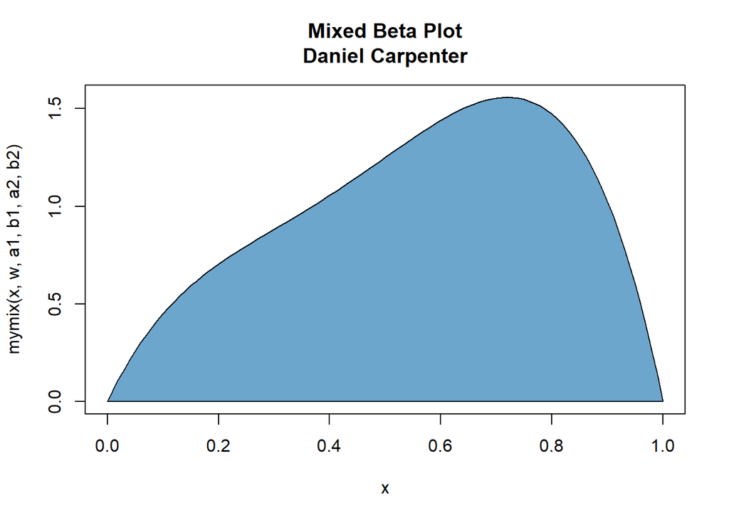

```r
Mymixplot <- function(w, a1,b1, a2,b2) {

  # Using mymix() to estimate mixed beta
  mymix<- function(x, w, a1,b1, a2,b2) {
    w*dbeta(x, a1, b1) +(1-w)*dbeta(x, a2,b2)
  }

  # Plot the curve and area with a title
  polygon(curve(mymix(x, w, a1,b1, a2,b2)), col = "skyblue3")
  title('Mixed Beta Plot\nDaniel Carpenter')
}

# Call the above function over various scenarios
Mymixplot(w=0.3, a1=2,b1=4, a2=4,b2=2)
```

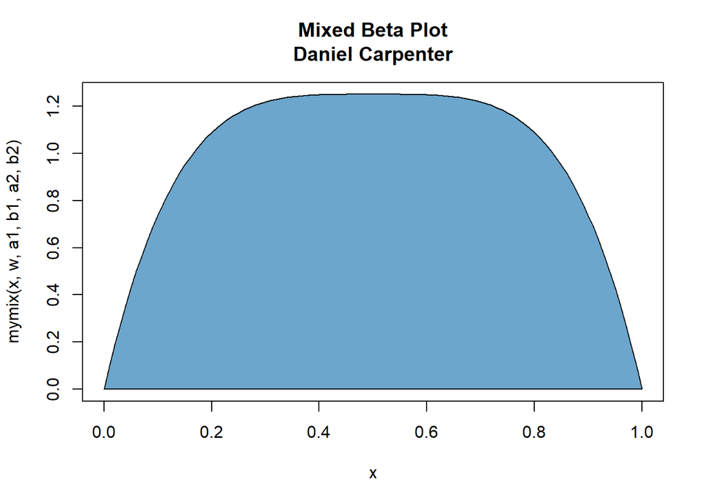

```r
Mymixplot(w=0.5, a1=2,b1=4, a2=4,b2=2)
```

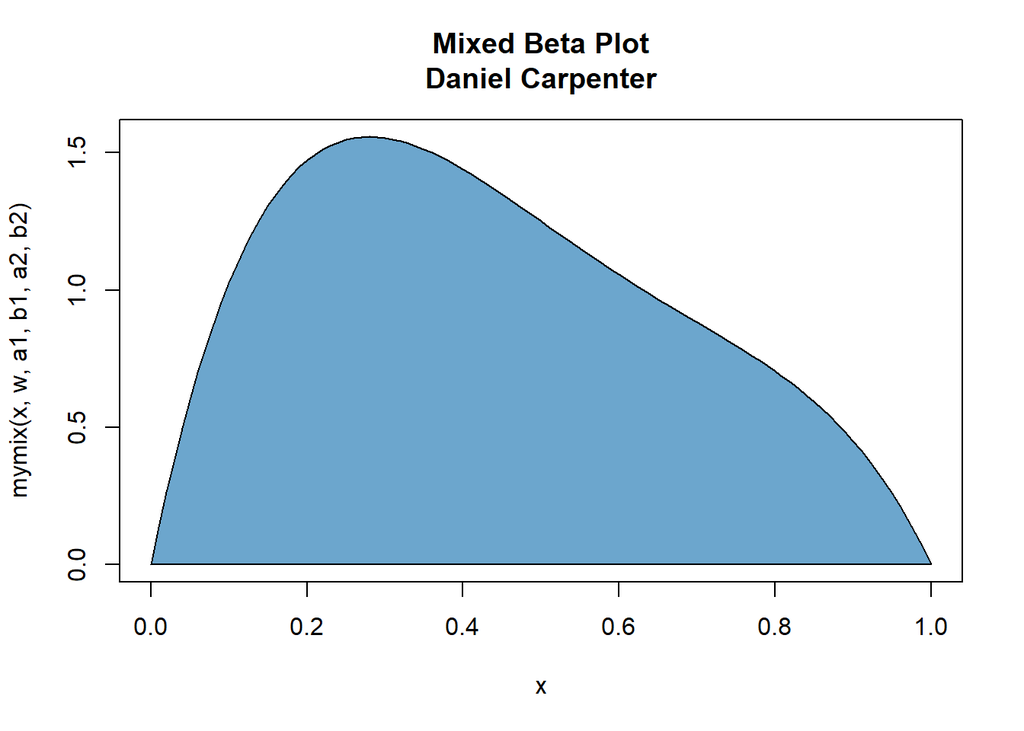

```r
Mymixplot(w=0.7, a1=2,b1=4, a2=4,b2=2)
```

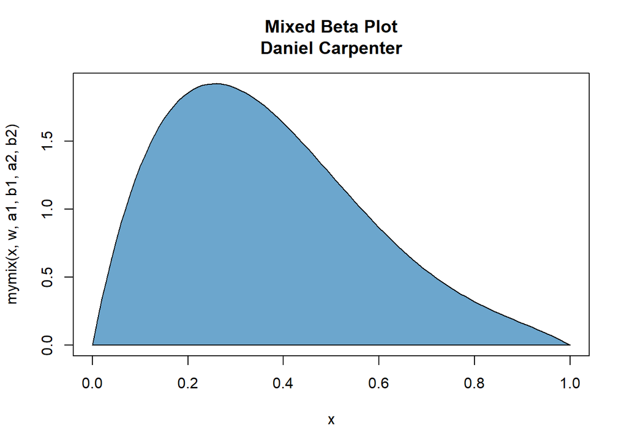

```r
Mymixplot(w=0.9, a1=2,b1=4, a2=4,b2=2)
```

## `d` `JAGS` Function with `Mixed-Beta Prior`

### `i` Analytical Posterior

$$\underbrace{\frac{z+a}{N+a+b}}_{\text{posterior}} = \underbrace{\frac{z}{N}}_{\text{data}} \underbrace{\frac{N}{N+a+b}}_{\text{weight}} + \underbrace{\frac{a}{a+b}}_{\text{prior}} \underbrace{\frac{a+b}{N+a+b}}_{\text{weight}} .$$

### `ii` Posterior Mixing Weight

- Posterior Mixing Weight is the weights applied to the two beta distributions to mix them

### `iii` Use a mixed beta as the prior

*Note that the code below is adapted from JK’s `BernBeta()` function - adjusted to take mixed beta priors*

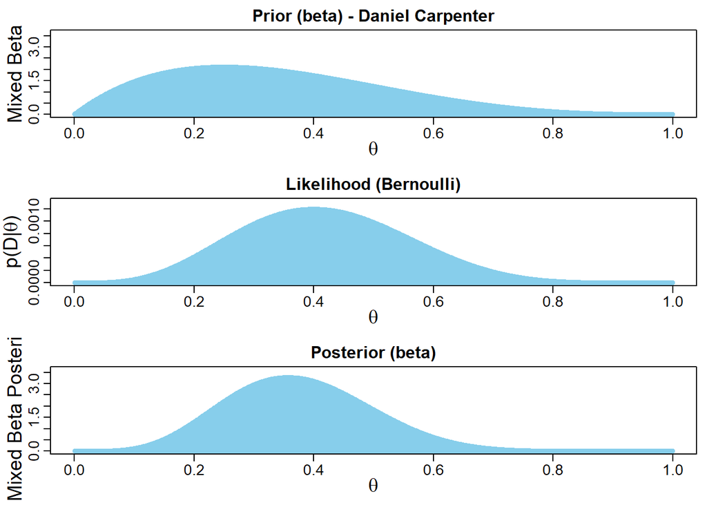

```r
Mymixbeta <- function(w=0.5, n=10, x, a1=1, a2=1, b1=1, b2=1) {
  # Specify the prior:
  t = x                          # Specify the prior MODE.

  # Specify the data:
  N = n                          # The total number of flips.
  z = x                          # The number of heads.
  Data = c(rep(0,N-z),rep(1,z))  # Convert N and z into vector of 0's and 1's.

  # Create summary values of Data:
  z = sum( Data ) # number of 1's in Data
  N = length( Data )

  Theta = seq(0.001,0.999,by=0.001)                                                 # points for plotting
  pTheta = w*dbeta(Theta,a1,b1) +(1-w)*dbeta(Theta,a2,b2)                           # prior for plotting
  pThetaGivenData = w*dbeta(Theta, a1+z, b1+N-z) + (1-w)*dbeta(Theta, a2+z, b2+N-z) # posterior for plotting
  pDataGivenTheta = Theta^z * (1-Theta)^(N-z)                                       # likelihood for plotting


  # Plot Layout
  layout( matrix( c( 1,2,3 ) ,nrow=3 ,ncol=1 ,byrow=FALSE ) ) # 3x1 panels
  par( mar=c(3,3,1,0) , mgp=c(2,0.7,0) , mai=c(0.5,0.5,0.3,0.1) ) # margins
  cexAxis = 1.33
  cexLab = 1.75

  # convert plotType to notation used by plot:
  plotType="h"
  dotsize = 5 # how big to make the plotted dots
  barsize = 5 # how wide to make the bar lines

  # y limits for prior and posterior:
  yLim = c(0,1.1*max(c(pTheta,pThetaGivenData)))


  # Plot the Prior
  plot( Theta , pTheta , type=plotType ,
        pch="." , cex=dotsize , lwd=barsize ,
        xlim=c(0,1) , ylim=yLim , cex.axis=cexAxis ,
        xlab=bquote(theta) , ylab='Mixed Beta' ,
        cex.lab=cexLab ,
        main="Prior (beta) - Daniel Carpenter" , cex.main=1.5 , col="skyblue")

  # Plot the likelihood
  plot( Theta , pDataGivenTheta , type=plotType ,
        pch="." , cex=dotsize , lwd=barsize ,
        xlim=c(0,1) , ylim=c(0,1.1*max(pDataGivenTheta)) , cex.axis=cexAxis ,
        xlab=bquote(theta) , ylab=bquote( "p(D|" * theta * ")" ) ,
        cex.lab=cexLab ,
        main="Likelihood (Bernoulli)" , cex.main=1.5 , col="skyblue" )

  # Plot the posterior.
  plot( Theta , pThetaGivenData , type=plotType ,
        pch="." , cex=dotsize , lwd=barsize ,
        xlim=c(0,1) , ylim=yLim , cex.axis=cexAxis ,
        xlab=bquote(theta) , ylab='Mixed Beta Posterior' ,
        cex.lab=cexLab ,
        main="Posterior (beta)" , cex.main=1.5 , col="skyblue" )
}

# Call the function and print the prior (mixed beta), likelihood and posterior)
Mymixbeta(w=0.5, n=10, x=4, a1=2, a2=2, b1=4, b2=4)
```

# Task `3` - Create JAGS Model using Mix Betas as Prior

## `a` `dcat()` Explained

- `dcat()` calculates the categorical likelihood given a categorical event vector `x` and the categorical event matrix `prob`
- Suppose a coin is either “unbiased” or “biased”. In which case the chance of a “head” is unknown and is given a uniform prior distribution. We assess a prior probability of 0.9 that it is “unbiased”, and then observe 15 heads out of 20 tosses.

## `b-e` Mixed Prior JAGS Function to Asses if Coin is Biased

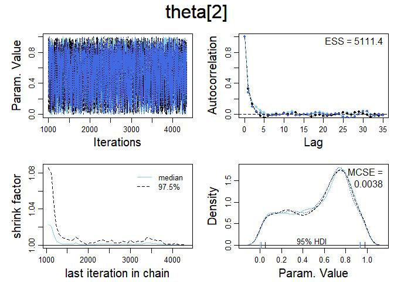

```r
mypriormix <- function() {

  # Optional generic preliminaries:
  graphics.off() # This closes all of R's graphics windows.
  rm(list=ls())  # Careful! This clears all of R's memory!


  # Load the functions used below:
  source("DBDA2E-utilities.R") # Must be in R's current working directory.
  require(rjags)               # Must have previously installed package rjags.

  fileNameRoot="Assn2Jags/" # For output file names.
  dir.create(fileNameRoot)

  # Load the data:
  Ntotal = 10  # Compute the total number of flips.
  dataList = list(x = 15, n = 20)

  # Define the model:
  modelString = "
  model {
    x ~ dbin( p, n ) p <- theta[pick]

    # pick is 2 if biased 1 unbiased
    pick ~ dcat(q[]) # categorical 1 produced prob q[1], etc

    q[1]<-0.9
    q[2]<-0.1
    theta[1] <-0.5        # unbiased
    theta[2] ~ dunif(0,1) # biased
    biased <- pick - 1
  }
  " # close quote for modelString
  writeLines( modelString , con="TEMPmodel.txt" )

  # Initialize the chains based on MLE of data.
  initsList = list( pick = 1)

  # Run the chains:
  jagsModel = jags.model( file="TEMPmodel.txt" , data=dataList , inits=initsList ,
                          n.chains=3 , n.adapt=500 )
  update( jagsModel , n.iter=500 )
  codaSamples = coda.samples( jagsModel , variable.names=c("theta[2]","biased","theta[1]") ,
                              n.iter=3334 )
  save( codaSamples , file=paste0(fileNameRoot,"Mcmc.Rdata") )

  # Examine the chains ----------------------------------------------------------

    # Convergence diagnostics:
    filename1 <- paste0(fileNameRoot,"Theta[2]Diag")
    diagMCMC( codaObject=codaSamples , parName="theta[2]" )
    saveGraph( file= filename1, type="jpg" )


    # Posterior descriptives:
    filename2 <- paste0(fileNameRoot,"Theta[2]Post")
    openGraph(height=3,width=4)
    par( mar=c(3.5,0.5,2.5,0.5) , mgp=c(2.25,0.7,0) )
    plotPost( codaSamples[,"theta[2]"] , main="theta[2]" , xlab=bquote(theta[2]) )
    saveGraph( file=filename2, type="jpg" )
    graphics.off() # this is done to prevent very last graph being displyed in RMD out


  # Summary Statistics/Point Estimates
  return(list(su = summary(codaSamples), codaSamples = codaSamples,
              diagGraph = paste0(filename1, '.jpg'), postGraph = paste0(filename2, '.jpg')))
}

mypriormix() -> ans
# Show Diagnostic graph
knitr::include_graphics(ans$diagGraph)
```

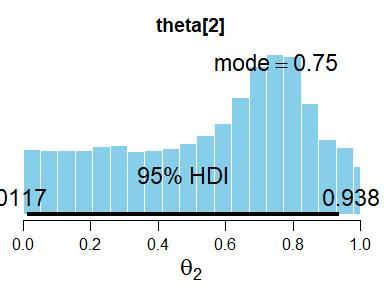

```r
# Show Posterior
knitr::include_graphics(ans$postGraph)
```

```r
# Point Estimates
ans$su
```

```
##
## Iterations = 1001:4334
## Thinning interval = 1
## Number of chains = 3
## Sample size per chain = 3334
##
## 1. Empirical mean and standard deviation for each variable,
##    plus standard error of the mean:
##
##            Mean     SD Naive SE Time-series SE
## biased   0.2621 0.4398 0.004398       0.006240
## theta[1] 0.5000 0.0000 0.000000       0.000000
## theta[2] 0.5560 0.2714 0.002714       0.003829
##
## 2. Quantiles for each variable:
##
##            2.5%    25%    50%   75%  97.5%
## biased   0.0000 0.0000 0.0000 1.000 1.0000
## theta[1] 0.5000 0.5000 0.5000 0.500 0.5000
## theta[2] 0.0319 0.3303 0.6237 0.775 0.9624
```

```r
head(ans$codaSamples)
```

```
## [[1]]
## Markov Chain Monte Carlo (MCMC) output:
## Start = 1001
## End = 1007
## Thinning interval = 1
##      biased theta[1]  theta[2]
## [1,]      1      0.5 0.7825123
## [2,]      1      0.5 0.7138804
## [3,]      1      0.5 0.8463350
## [4,]      0      0.5 0.4577871
## [5,]      0      0.5 0.7657102
## [6,]      1      0.5 0.4337847
## [7,]      0      0.5 0.8869759
##
## [[2]]
## Markov Chain Monte Carlo (MCMC) output:
## Start = 1001
## End = 1007
## Thinning interval = 1
##      biased theta[1]   theta[2]
## [1,]      0      0.5 0.97930286
## [2,]      0      0.5 0.24585767
## [3,]      0      0.5 0.03456931
## [4,]      0      0.5 0.10738758
## [5,]      0      0.5 0.06230670
## [6,]      0      0.5 0.75587984
## [7,]      1      0.5 0.71733173
##
## [[3]]
## Markov Chain Monte Carlo (MCMC) output:
## Start = 1001
## End = 1007
## Thinning interval = 1
##      biased theta[1]  theta[2]
## [1,]      0      0.5 0.7539043
## [2,]      0      0.5 0.9365102
## [3,]      0      0.5 0.7212802
## [4,]      0      0.5 0.2585593
## [5,]      0      0.5 0.6151178
## [6,]      0      0.5 0.4435938
## [7,]      0      0.5 0.4376622
##
## attr(,"class")
## [1] "mcmc.list"
```

# Task `4` - Note that Posterior is Incorrect

## `a` Data Structure

> structure of the MCMC data in the file produced by the jags script

```r
class(ans$codaSamples) # Class is a list
```

```
## [1] "mcmc.list"
```

```r
str(ans$codaSamples)   # Structure of the mcmc list
```

```
## List of 3
##  $ : 'mcmc' num [1:3334, 1:3] 1 1 1 0 0 1 0 0 0 0 ...
##   ..- attr(*, "dimnames")=List of 2
##   .. ..$ : NULL
##   .. ..$ : chr [1:3] "biased" "theta[1]" "theta[2]"
##   ..- attr(*, "mcpar")= num [1:3] 1001 4334 1
##  $ : 'mcmc' num [1:3334, 1:3] 0 0 0 0 0 0 1 1 0 0 ...
##   ..- attr(*, "dimnames")=List of 2
##   .. ..$ : NULL
##   .. ..$ : chr [1:3] "biased" "theta[1]" "theta[2]"
##   ..- attr(*, "mcpar")= num [1:3] 1001 4334 1
##  $ : 'mcmc' num [1:3334, 1:3] 0 0 0 0 0 0 0 0 0 0 ...
##   ..- attr(*, "dimnames")=List of 2
##   .. ..$ : NULL
##   .. ..$ : chr [1:3] "biased" "theta[1]" "theta[2]"
##   ..- attr(*, "mcpar")= num [1:3] 1001 4334 1
##  - attr(*, "class")= chr "mcmc.list"
```

## `b` `mcmcT`

> Combine estimates into a data frame

```r
# Use codaSamples to get the Monitored Variables - show head too
mcmc1 = as.data.frame(ans$codaSamples[[1]]); head(mcmc1)
```

```
##   biased theta[1]  theta[2]
## 1      1      0.5 0.7825123
## 2      1      0.5 0.7138804
## 3      1      0.5 0.8463350
## 4      0      0.5 0.4577871
## 5      0      0.5 0.7657102
## 6      1      0.5 0.4337847
```

```r
mcmc2 = as.data.frame(ans$codaSamples[[2]]); head(mcmc2)
```

```
##   biased theta[1]   theta[2]
## 1      0      0.5 0.97930286
## 2      0      0.5 0.24585767
## 3      0      0.5 0.03456931
## 4      0      0.5 0.10738758
## 5      0      0.5 0.06230670
## 6      0      0.5 0.75587984
```

```r
mcmc3 = as.data.frame(ans$codaSamples[[3]]); head(mcmc3)
```

```
##   biased theta[1]  theta[2]
## 1      0      0.5 0.7539043
## 2      0      0.5 0.9365102
## 3      0      0.5 0.7212802
## 4      0      0.5 0.2585593
## 5      0      0.5 0.6151178
## 6      0      0.5 0.4435938
```

```r
# make mcmcT by combining above
mcmcT = rbind.data.frame(mcmc1,mcmc2,mcmc3)
```

## `c` Plots

> Create plots of biased and unbiased posterior *without* pseudo priors used

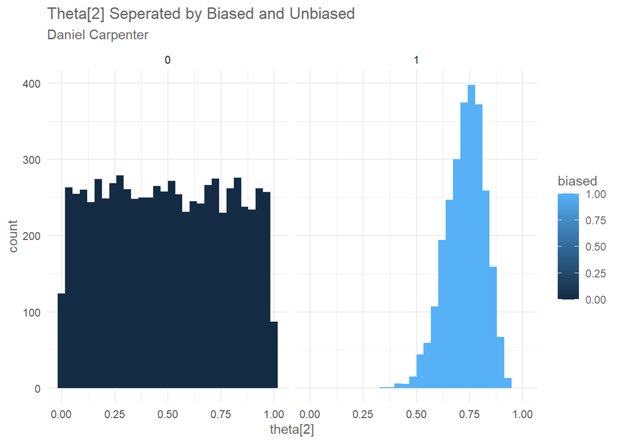

```r
require(ggplot2)

# Show biased and unbiased posteriors
ggplot(mcmcT, aes(x = `theta[2]`, fill = biased)) +
  geom_histogram() + # Create a  hist layer
  facet_wrap(~biased) +
  labs(title = 'Theta[2] Seperated by Biased and Unbiased',
  subtitle = 'Daniel Carpenter') +
  theme_minimal() + theme(text = element_text(color = '#666666'))
```

## `d` Interpretation of Pick

`i.` When the parameter `biased` = 0: `pick` = $1$, `ii.` When the parameter `biased` = 1: `pick` = $2$,

## `e` Incorrect Posterior

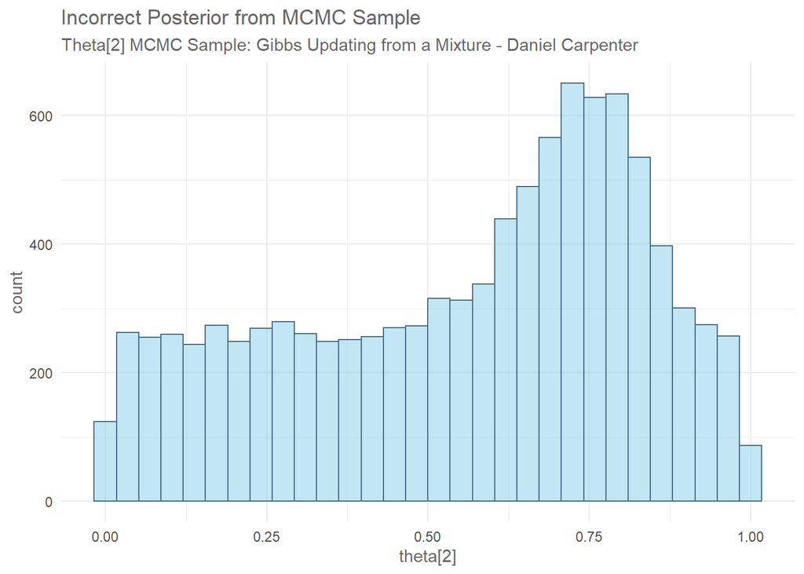

```r
# Show incorrect posterior
ggplot(mcmcT, aes(x = `theta[2]`)) +
  geom_histogram(color = 'skyblue4', fill = 'skyblue', alpha = 0.5) + # Create a  hist layer
  labs(title = 'Incorrect Posterior from MCMC Sample',
  subtitle = 'Theta[2] MCMC Sample: Gibbs Updating from a Mixture - Daniel Carpenter') +
  theme_minimal() + theme(text = element_text(color = '#666666'))
```

`vii.` The above plot has the shape because it includes both pick 1 and pick 2, which we instead could sample on the posterior to get a more informed prior for an additional sample.

# Task `5` - Correct Posterior by using Pseudo-Priors

> Must use `pseudo prior`, *or the posterior from the first JAGS run*, then run model again  
> Then, the posterior distribution will be correct

## `a` Derivation

- See JK’s *Inferring a Binomial Probability via Exact Mathematical Analysis, page 131*
- For a beta density with mean $\mu$ and standard deviation $\sigma$, the shape parameters are:

$$a=\mu\left(\frac{\mu(1-\mu)}{\sigma^{2}}-1\right)$$
$$b=(1-\mu)\left(\frac{\mu(1-\mu)}{\sigma^{2}}-1\right)$$

Derivation

$$\text { Given } \mu=\frac{a}{a+b}, \sigma^{2}=\frac{\mu(1-\mu)}{a+b+1}, a=\mu \kappa, b=(1-\mu) \kappa \text {, and } \kappa=a+b$$

## `b-e` `pseudobin()` - Use Pseudo Priors for Prior

```r
# function that will create a list of the hyper-parameter estimates
# using the summary stats from a previous run of the MCMC sampler
pseudobin <- function(lastPick) {

  # Function to get alpha and beta from mean and sigma (for pseudo prior)
  mustoab <- function (mu, sigma) {

    # Convert mu and sigma to shapes
    a =     (mu) * (mu*(1 - mu) / (sigma^2)-1)
    b = (1 - mu) * (mu*(1 - mu) / (sigma^2)-1)

    return(list(a=a, b=b))
  }

  # Get alpha and beta for pseudo prior
  mu = mean(lastPick$`theta[2]`)
  sd = sqrt(var(lastPick$`theta[2]`))
  shapeParamsForPseudo <- mustoab(mu, sd)

  # JAGS model ------------------------------------------------------------------

    # Optional generic preliminaries:
    graphics.off() # This closes all of R's graphics windows.

    # Load the functions used below:
    source("DBDA2E-utilities.R") # Must be in R's current working directory.
    require(rjags)               # Must have previously installed package rjags.

    fileNameRoot="Assn2JagsPseudo/" # For output file names.
    dir.create(fileNameRoot)

    # Load the data:
    Ntotal = 10  # Compute the total number of flips.
    dataList = list(x = 15, n = 20,
                    alpha = shapeParamsForPseudo$a,
                    beta  = shapeParamsForPseudo$b
                    )

    # Define the model:
    modelString = "
      model {
      x ~ dbin(p,n)
      p <- theta[pick]

      # theta[1] represents fixed unbiased value
      theta[1] <- equals(pick,1)*fixtheta1 + equals(pick,2)*fixtheta1
      theta[2] <- equals(pick,1)*pseudotheta2 + equals(pick,2)*theta2

      # pick is 2 if biased 1 unbiased
      pick ~ dcat(q[]) # categorical 1 produced prob q[1], etc

      q[1]<-0.9
      q[2]<-0.1
      fixtheta1 <-0.5     # unbiased; fixed probability

      theta2 ~ dunif(0,1) # true prior of theta[2]

      # shape parameters for pseudo prior will be part of dataList
      pseudotheta2 ~ dbeta(alpha,beta)
      biased <- pick - 1
    }
    " # close quote for modelString

    writeLines( modelString , con="TEMPmodel.txt" )

    # Initialize the chains based on MLE of data.
    initsList = list( pick = 1)

    # Run the chains:
    jagsModel = jags.model( file="TEMPmodel.txt" , data=dataList , inits=initsList ,
                            n.chains=3 , n.adapt=500 )
    update( jagsModel , n.iter=500 )
    codaSamples = coda.samples( jagsModel , variable.names=c("theta[2]","biased","theta[1]") ,
                                n.iter=3334 )
    save( codaSamples , file=paste0(fileNameRoot,"Mcmc.Rdata") )

    # Examine the chains ----------------------------------------------------------

      # Convergence diagnostics:
      filename1 <- paste0(fileNameRoot,"Theta[2]Diag")
      diagMCMC( codaObject=codaSamples , parName="theta[2]" )
      saveGraph( file= filename1, type="jpg" )


      # Posterior descriptives:
      filename2 <- paste0(fileNameRoot,"Theta[2]Post")
      openGraph(height=3,width=4)
      par( mar=c(3.5,0.5,2.5,0.5) , mgp=c(2.25,0.7,0) )
      plotPost( codaSamples[,"theta[2]"] , main="theta[2]" , xlab=bquote(theta[2]) )
      saveGraph( file=filename2, type="jpg" )
      graphics.off() # this is done to prevent very last graph being displyed in RMD out


    # PLOTS - Example codaSamples -------------------------------------------------

      # Use codaSamples to get the Monitored Variables - show head too
      mcmc1 = as.data.frame(codaSamples[[1]])
      mcmc2 = as.data.frame(codaSamples[[2]])
      mcmc3 = as.data.frame(codaSamples[[3]])

      # make mcmcT by combining above
      mcmcT = rbind.data.frame(mcmc1,mcmc2,mcmc3)

      # Get pick 2 and view
      # pick2 = subset(mcmcT, biased == 1) # COMMENT OUT LATER
      # plot(codaSamples[ ,"theta[2]"])    # COMMENT OUT LATER
      # with(pick2, hist(`theta[2]`))      # COMMENT OUT LATER

      require(ggplot2)

      # Show biased and unbiased posteriors
      biasPlot <- ggplot(mcmcT, aes(x = `theta[2]`, fill = biased)) +
                  geom_histogram() + # Create a  hist layer
                  facet_wrap(~biased) +
                  labs(title = 'Theta[2] Seperated by Biased and Unbiased',
                       subtitle = 'Daniel Carpenter') +
                  theme_minimal() + theme(text = element_text(color = '#666666'))
      biasPlot

      # Show Posterior
      postPlot <- ggplot(mcmcT, aes(x = `theta[2]`)) +
                    geom_histogram(color = 'skyblue4', fill = 'skyblue', alpha = 0.5) + # Create a  hist layer
                    labs(title = 'Posterior from MCMC Sample',
                         subtitle = 'Theta[2] MCMC Sample: Gibbs Updating from a Mixture - Daniel Carpenter') +
                    theme_minimal() + theme(text = element_text(color = '#666666'))
      postPlot

      # Save and print the plots
      dir.create('Plots/')
      fileName1 = 'Plots/biasPlot.png'; ggsave(biasPlot, file=fileName1)
      fileName2 = 'Plots/postPlot.png'; ggsave(postPlot, file=fileName2)

      require(knitr) # for kable

    return(list(hyperParams = list(alpha = shapeParamsForPseudo$a, beta  = shapeParamsForPseudo$b),
                su = kable(summary(codaSamples)$statistics),
                plot1File = fileName1, plot2File = fileName2))
}

# Optional plots
# plot(codaSamples[ ,"theta[2]"])  # Some other plots
# with(pick2, hist(`theta[2]`))    # Some other plots

# Get pick 1 and pick 2 from past model
pick1 = subset(mcmcT, biased == 0)
pick2 = subset(mcmcT, biased == 1)

# Use pick 2 of the past model for the pseudo prior
pseudobin(pick2) -> pseudoAns
# See the hyper parameters
pseudoAns$hyperParams
```

```
## $alpha
## [1] 16.72809
##
## $beta
## [1] 6.214912
```

```r
# See the summary stats also
pseudoAns$su
```

|  | Mean | SD | Naive SE | Time-series SE |
| --- | --- | --- | --- | --- |
| biased | 0.2583483 | 0.4377484 | 0.0043770 | 0.0062446 |
| theta[1] | 0.5000000 | 0.0000000 | 0.0000000 | 0.0000000 |
| theta[2] | 0.7278250 | 0.0923744 | 0.0009237 | 0.0010882 |

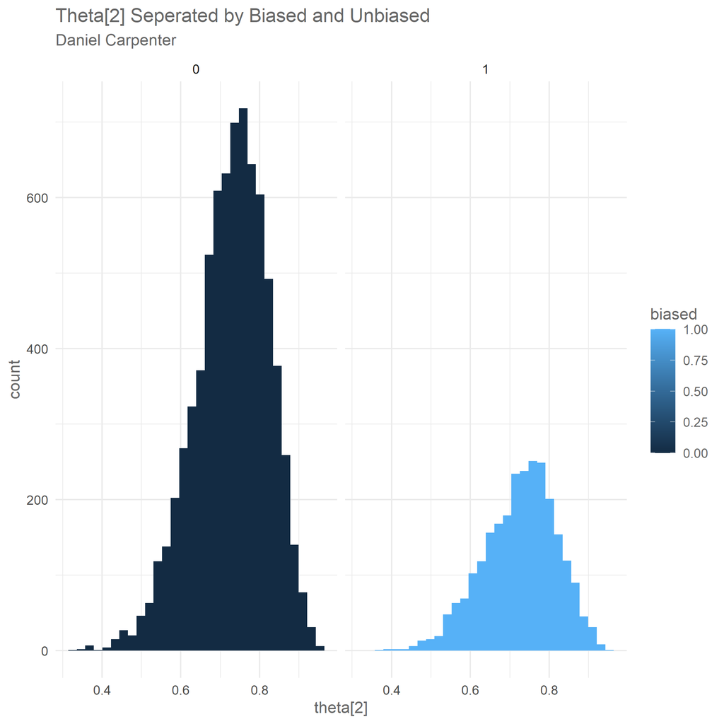

```r
# Show the Plots
knitr::include_graphics(pseudoAns$plot1File)
```

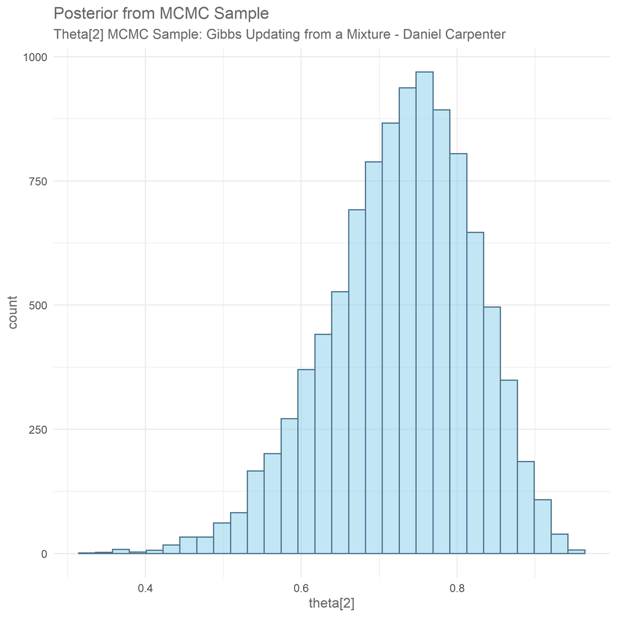

```r
knitr::include_graphics(pseudoAns$plot2File)
```

### Interpretation for Problem `b. iii.` and `e`

`b. iii.` The part used is pick 2. Notice the difference between the posterior of this model vs. this first.  
`e` There are more counts in the first facet since the estimate is less biased and represents the model better now.